# Milestone Report

Wei-Meng Lee

30 March 2015

# Executive Summary

This document contains an exploratory data analysis of the data provided for the Johns Hopkins Data Science Specialisation capstone project, as well as the general approach to be taken for design of the prediction algorithm.

This report is meant to demonstrate that the data was successfully downloaded and loaded, report any interesting findings and gather feedback on plans for the prediction algorithmn and eventual Shiny app.

# Data Summary

## Source

The dataset (which can be downloaded [here](https://d396qusza40orc.cloudfront.net/dsscapstone/dataset/Coursera-SwiftKey.zip)) is prepared for the Johns Hopkins Data Science Capstone course, based on a corpus called HC Copora. The corpora are English-language samples collected from blogs, newspapers and Twitter by a web crawler and included in three text files: `en_US.blogs.txt`, `en_US.news.txt` and `en_US.twitter.txt` respectively.

More information on how the original corpora were collected is available [here](http://www.corpora.heliohost.org/aboutcorpus.html).

## Exploratory Data Analysis

An initial exploration of each text file’s word and line count was performed using the Unix `wc` utility. The results are presented below:

|  | blogs | news | twitter | total |
| --- | --- | --- | --- | --- |
| Size (MB) | 210.2 | 205.8 | 167.1 | 583.1 |
| Number of lines | 899,288 | 1,010,242 | 2,360,148 | 4,269,678 |
| Number of words | 37,334,690 | 34,372,720 | 30,374,206 | 102,081,616 |
| Average words per line | 41.5 | 34.0 | 12.9 | 23.9 |

As expected, text sources from Twitter have significantly lesser words per line as compared to blogs and newspapers due to the 160-character limit of the medium. Blogs and newspapers are more alike, with blogs appearing to have more words per line of text.

For the next part of the analysis, a sample representing approximately 5 percent of each corpus was taken. Each sample is meant to be representative of the population and was collected using the following function:

```r
set.seed(42)

sampleCorpus <- function(corpus) {
  corpus.sample.nlines <- length(corpus) * 0.05
  corpus.sample <- sample(corpus, corpus.sample.nlines)
  return(corpus.sample)
}
```

Each sample is then cleaned up, with character encoding and case standardised, and punctuation, whitespace and numbers removed. The following function was used to achieve this:

```r
corpusCleanup <- function(corpus) {
  corpus <- tm_map(corpus, content_transformer(iconv), from = "latin1", to = "ASCII", sub = "")
  corpus <- tm_map(corpus, content_transformer(tolower))
  corpus <- tm_map(corpus, removePunctuation)
  corpus <- tm_map(corpus, stripWhitespace)
  corpus <- tm_map(corpus, removeNumbers)
  return(corpus)
}
```

Stop words were not removed at this stage as it is believed that they – together with bi-grams, tri-grams and 4-grams – will form part of the future prediction algorithm.

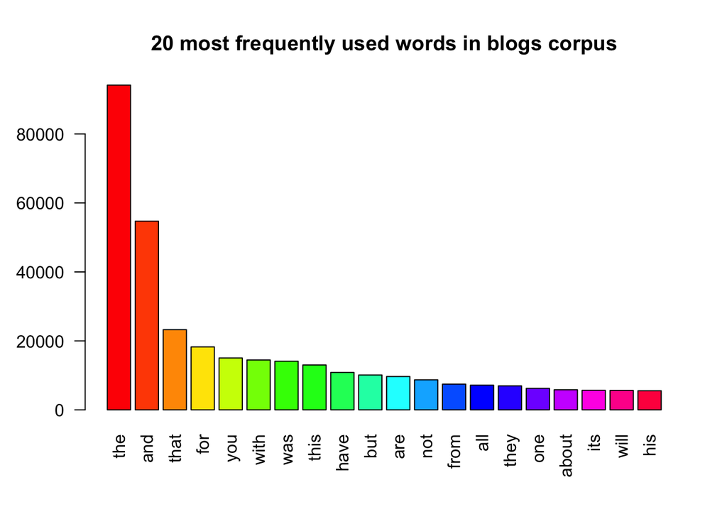

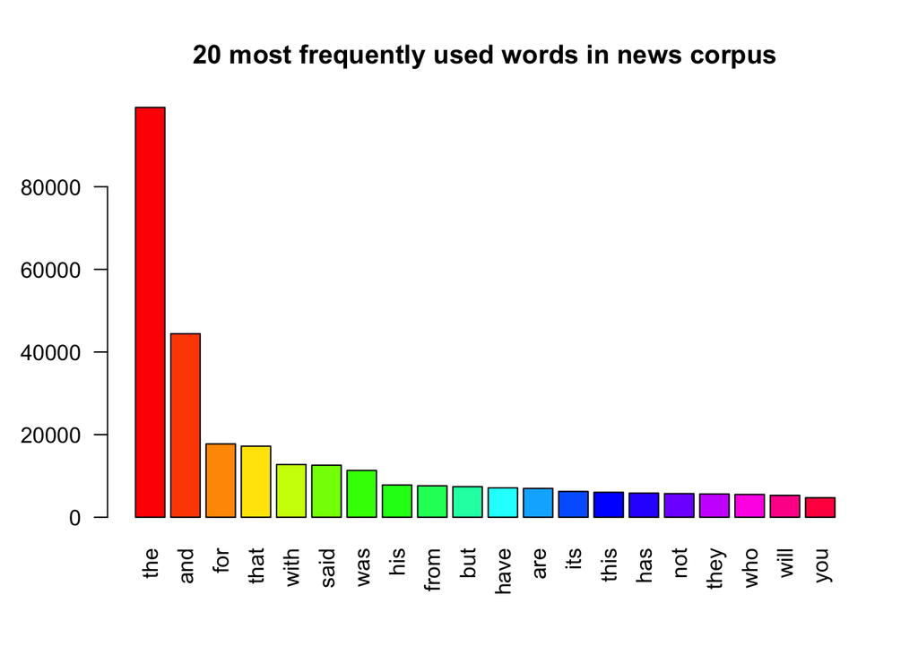

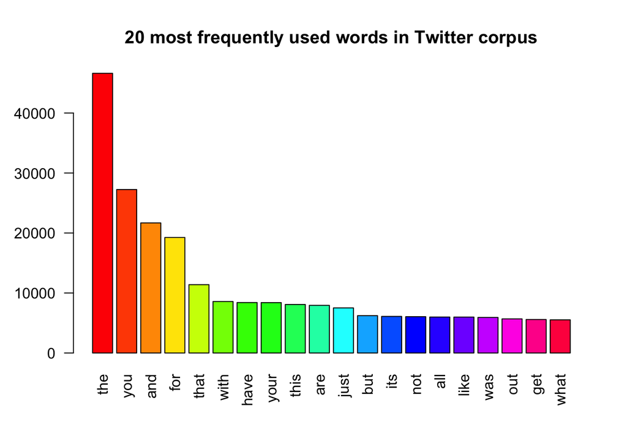

# Prediction Algorithm

While several steps have been identified to pre-process the corpora above (removal of whitespace characters, conversion to lowercase, etc.), additional steps may be added for the final algorithm. Some of the steps that are under consideration include:

- the removal of profanity
- the removal of stop words
- use of the `qdap` package to correct spelling errors

In addition, the frequency of bi-grams, tri-grams and 4-grams will have to be calculated to help train the prediction model.

Throughout the design of the algorithm, the primary considerations are speed, followed by accuracy. Speed of the algorithm is more important than accuracy as the final product will be a Shiny web app that is expected to deliver near-instantaneous predictions based on user input. The product would be of no use if the user’s need for instantaneous predictions are not satisfied.